# MCCS IPW Case-Cohort Simulation Results

Brian Richardson

04/08/2024

```r
rm(list = ls())
library(dplyr)
library(tidyverse)
library(ggplot2)
library(ggh4x)
library(kableExtra)
```

The goal of this program is to evaluate the Monte Carlo corrected score inverse probability weighting (MCCS IPW) estimator in the presence of confounding and measurement error.

## Setup

Consider the following setup:

- continuous confounder $L \sim U(0, 1)$,
- trivariate continuous exposure $\pmb{A} = (A_1, A_2, A_3)^T$ with $\pmb{A}|L$ having multivariate normal distribution $N_3\left(\begin{bmatrix} 0.4L \\ -0.4L \\ 0.2 - 0.1L \end{bmatrix}, \begin{bmatrix} 0.09 & 0 & 0 \\ 0 & 0.09 & 0 \\ 0 & 0 & 0.09 \end{bmatrix}\right)$.
- mismeasured exposure $\pmb{A}^* = (A^*_1, A^*_2, A^*_3)^T = \pmb{A} + \pmb{\epsilon}$, where $\pmb{\epsilon} = (\epsilon_1, \epsilon_2, \epsilon_3)^T \sim N(\pmb{0}, \pmb{\Sigma}_e)$, $\pmb{\Sigma}_e = \begin{bmatrix} \sigma_e^2 & 0 & 0 \\ 0 & \sigma_e^2 & 0 \\ 0 & 0 & 0\end{bmatrix}$.
- binary outcome $Y$ with $\textrm{E}(Y|\pmb{A},L) = \widetilde\gamma_0 + \widetilde\gamma_1 a_1 + \widetilde\gamma_2 a_2 + \widetilde\gamma_3 a_3 + \widetilde\gamma_4L + \widetilde\gamma_5 a_1L + \widetilde\gamma_6 a_2L + \widetilde\gamma_7 a_3L$, where $\widetilde{\pmb{\gamma}} = (\widetilde\gamma_0, \widetilde\gamma_1, \widetilde\gamma_2, \widetilde\gamma_3, \widetilde\gamma_4, \widetilde\gamma_5, \widetilde\gamma_6, \widetilde\gamma_7)^T = (0.4, 0.15, 0.15, 0.2, 0.1, 0.1, 0, -0.1)^T$.

This data generating process leads to the marginal structural model $\textrm{E}\{Y(\pmb{a})\} = \gamma_0 + \gamma_1 a_1 + \gamma_2 a_2 + \gamma_3 a_3$, where $\pmb{\gamma} = (\gamma_0, \gamma_1, \gamma_2, \gamma_3)^T = (0.45, 0.2, 0.15, 0.15)^T$.

The estimand of interest in these simulations is the parameter $\pmb{\gamma}$ in the marginal structural model.

## Methods

In these simulations, we compare six methods:

1. Oracle Regression Model
2. Oracle IPW
3. Naive Regression Model
4. Naive IPW
5. Corrected Regression Model
6. Corrected IPW

To construct the standardized weights for the oracle and naive IPW estimators, the normal densities $f_{\pmb{A}}$ and $f_{\pmb{A}|L}$ need to be estimated. For the numerator, the sample mean and covariance of $\pmb{A}$ are used. For the denominator, a linear model $\pmb{A} \sim L$ is fit, where it is assumed/known that $A_1, A_2, A_3$ are conditionally independent given $L$.

To construct the standardized weights for the corrected IPW estimator, $f_{\pmb{A}}$ and $f_{\pmb{A}|L}$ need to be estimated using $\pmb{A}^*$. Since $\pmb{A}$ and $\pmb{\epsilon}$ are independent multivariate normal, $\textrm{E}(\pmb{A})$ can be estimated with the sample mean of $\pmb{A}^*$, and $\textrm{Cov}(\pmb{A})$ with the sample covariance of $\pmb{A}^*$ minus $\pmb{\Sigma}_e$. Likewise, since, conditional on $L$, $\pmb{A}$ and $\pmb{\epsilon}$ are independent multivariate normal, estimated coefficients from the linear model $\pmb{A}^* \sim L$ are consistent for the coefficients of $\pmb{A} \sim L$, and the conditional covariance of $\pmb{A} | L$ can be estimated by subtracting $\pmb{\Sigma}_e$ from the residual covariance of the model $\pmb{A}^* \sim L$.

For both the oracle and MCCS IPW estimators, estimating equations for the estimated weights and for the outcome model are stacked. This is necessary for sandwich variance estimators to be consistent.

## Results

```r
# load simulation results from each of 10 clusters
sim.out.list <- lapply(
  X = 0:9,
  FUN = function(clust) {
    cbind(clust,
          read.csv(paste0("sim_data/ipw_cc_data/v2/sd",
                          clust, ".csv")))
  })


# combine simulation results into 1 data frame
sim.out <- bind_rows(sim.out.list)

# true MSM parameters
g <- c(0.45, 0.20, 0.15, 0.15)

# number of sims per setting
n.rep <- nrow(sim.out) / n_distinct(dplyr::select(sim.out, n, B, vare))

# make long data frame
sim.out.long <- sim.out %>%
  pivot_longer(cols = starts_with("ghat") | starts_with("stde"),
               names_to = "method.param",
               values_to = "val") %>%
    mutate(method = factor(substr(method.param, 6, 7),
                           levels = c("OL", "OI",
                                      "NL", "NI",
                                      "CL", "CI"),
                           labels = c("Oracle Regression",
                                      "Oracle IPW",
                                      "Naive Regression",
                                      "Naive IPW",
                                      "Corrected Regression",
                                      "Corrected IPW")),
           param = factor(substr(method.param, 9, 9)),
           name = factor(substr(method.param, 1, 4)),
           g.true = g[param]) %>%
  dplyr::select(-method.param) %>%
  group_by(clust, n, B, vare, pi.cc, method, param, name) %>%
  mutate(id = row_number()) %>%
  pivot_wider(names_from = name,
              values_from = val,
              id_cols = c(clust, n, B, vare, pi.cc, method,
                          param, g.true, id)) %>%
  mutate(ci.lower = ghat - qnorm(0.975) * stde,
         ci.upper = ghat + qnorm(0.975) * stde,
         ci.cov = g.true >= ci.lower & g.true <= ci.upper)
```

We first check for simulations with errors.

```r
# summarize proportion of missing data by setting
sim.out.long %>%
  filter(param == 1) %>%
  group_by(method, n, pi.cc) %>%
  summarise(prop.error = mean(is.na(ghat))) %>%
  filter(prop.error > 0) %>%
  ungroup()
```

```
## # A tibble: 0 × 4
## # ℹ 4 variables: method <fct>, n <int>, pi.cc <dbl>, prop.error <dbl>
```

### Plots of simulation results

Below are boxplots of the empirical distributions of estimators for $\pmb{\gamma}$.

```r
# extract simulation parameters
n <- unique(sim.out$n)
pi.cc <- unique(sim.out$pi.cc)

# make labels for plots
n.labs <- paste0("n = ", n)
names(n.labs) <- n

pi.cc.labs <- paste0("pi.cc = ", pi.cc)
names(pi.cc.labs) <- pi.cc

param.labs <- paste0("\u03b3", c("0", "1", "2", "3"))
names(param.labs) <- 1:4

# colorblind friendly pallette
pal_light <- c('#EE6677', '#228833', '#4477AA', '#CCBB44', '#66CCEE', '#AA3377', '#BBBBBB')
pal_dark <- c('#991122', '#114419', '#223b55', '#6b611d', '#117799', '#55193b', '#5d5d5d')
```

```r
# create plots
make.plot <- function(title = T) {

  plot <- ggplot(
    data = sim.out.long,
    aes(x = method,
        y = ghat,
        fill = method,
        color = method)) +
    geom_boxplot() +
    stat_summary(fun = mean,
                 geom = "point",
                 shape = 8,
                 size = 2,
                 orientation = "x",
                 show.legend = F) +
    geom_hline(aes(yintercept = g.true),
               linetype = "dashed",
               color = "orange") +
    facet_nested(n + pi.cc ~ param,
                 scales = "free",
                 labeller = labeller(n = n.labs,
                                     param = param.labs)) +
    labs(y = "Parameter Estimate",
         fill = "Method",
         color = "Method") +
    theme_bw() +
    theme(axis.title.x = element_blank(),
          axis.ticks.x = element_blank(),
          axis.text.x = element_blank(),
          legend.position = "bottom") +
    scale_fill_manual(values = pal_light) +
    scale_color_manual(values = pal_dark)

  if (title) {
    plot <- plot +
      ggtitle(paste0("Empirical Distribution of Parameter Estimates"),
            subtitle = paste0(n.rep, " simulations per setting"))
  }
  return(plot)
}
```

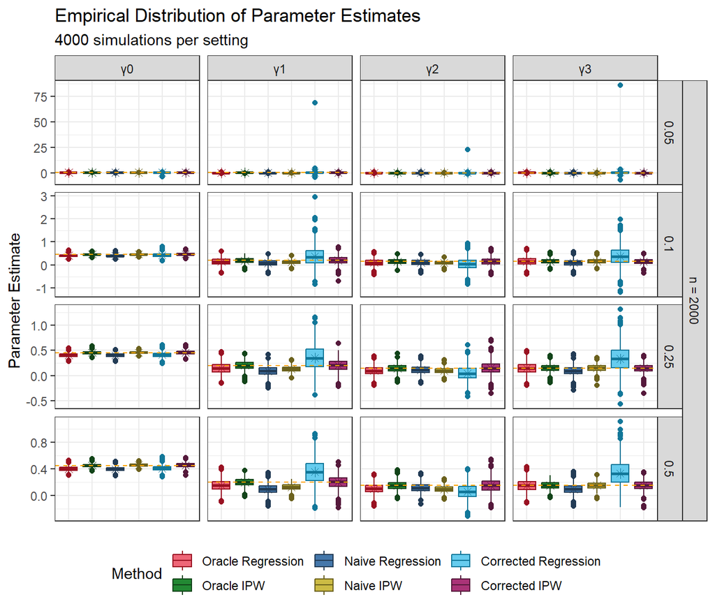

```r
make.plot()
```

### Table of Simulation Results

Below is a table of the empirical bias, empirical standard error, mean estimated standard error, and empirical coverage probability of the 95% CIs corresponding to $\widehat{\pmb{\gamma}}$, only for the corrected IPW estimators.

```r
tbl <- sim.out.long %>%
  filter(method == "Corrected IPW") %>%
  mutate(Param = paste0("$\\gamma_", param, "$"),
         pi.cc = 100 * pi.cc) %>%
  group_by(pi.cc, Param) %>%
  summarise(bias = 100 * mean(ghat - g.true, na.rm = T),
            emp.se = 100 * sd(ghat, na.rm = T),
            est.se = 100 * mean(stde),
            ci.cov = 100 * mean(ci.cov, na.rm = T))
kbl <- tbl %>%
  kable(#format = "latex",
        digits = 1,
        align = c(rep("c", 3),
                  rep("r", 4)),
        booktabs = TRUE,
        linesep = c("", "", "", "\\addlinespace"),
        escape = FALSE,
        col.names = c("pi.cc", "Parameter",
                      "Bias", "ESE", "ASE", "CI Coverage")) %>%
  kable_styling("striped") %>%
  row_spec(row = 0, bold = TRUE)

kbl
```

| pi.cc | Parameter | Bias | ESE | ASE | CI Coverage |
| --- | --- | --- | --- | --- | --- |
| 5 | $\gamma_1$ | 3.4 | 7.6 | 7.0 | 89.3 |
| 5 | $\gamma_2$ | 1.2 | 22.3 | 18.0 | 84.9 |
| 5 | $\gamma_3$ | 0.8 | 22.8 | 18.6 | 86.5 |
| 5 | $\gamma_4$ | -0.1 | 16.2 | 13.4 | 87.6 |
| 10 | $\gamma_1$ | 1.8 | 5.9 | 5.5 | 89.8 |
| 10 | $\gamma_2$ | 0.8 | 17.4 | 13.8 | 86.0 |
| 10 | $\gamma_3$ | -0.2 | 16.7 | 14.0 | 87.6 |
| 10 | $\gamma_4$ | 0.0 | 12.4 | 10.5 | 89.9 |
| 25 | $\gamma_1$ | 0.7 | 4.4 | 4.0 | 90.9 |
| 25 | $\gamma_2$ | 0.4 | 12.2 | 10.3 | 89.8 |
| 25 | $\gamma_3$ | -0.5 | 12.2 | 10.3 | 91.4 |
| 25 | $\gamma_4$ | -0.1 | 8.8 | 7.7 | 91.2 |
| 50 | $\gamma_1$ | 0.4 | 3.7 | 3.3 | 91.1 |
| 50 | $\gamma_2$ | 0.2 | 10.0 | 8.4 | 90.3 |
| 50 | $\gamma_3$ | -0.1 | 10.0 | 8.4 | 90.1 |
| 50 | $\gamma_4$ | -0.1 | 6.8 | 6.2 | 93.4 |